# Corrigé — Contrôle Continu SIASS

- Montrer tout le code
- Cacher tout le code
- Voir les sources

Analyse électorale et socio-économique des arrondissements parisiens (Présidentielle 2017)

Auteur·rice

Marc O’Flaherty

Date de publication

23 mars 2026

# 1 Partie 1 : Correction des calculs

## 1.1 Q1 — Statistiques descriptives

Calculons les indicateurs de position et de dispersion pour toutes les variables.

**NoteFormules Excel correspondantes**

| Indicateur | Formule Excel |
| --- | --- |
| **Min** | `=MIN(Plage)` |
| **Max** | `=MAX(Plage)` |
| **Quartile 1 (Q1)** | `=QUARTILE.EXC(Plage; 1)` |
| **Médiane (Q2)** | `=MEDIANE(Plage)` |
| **Quartile 3 (Q3)** | `=QUARTILE.EXC(Plage; 3)` |
| **EIQ** | `= Q3 - Q1` (calcul manuel) |
| **Variance** | `=VAR.S(Plage)` |
| **Écart-type** | `=ECARTYPE.STANDARD(Plage)` |

**Voir le code R**

```r
# Calcul des indicateurs pour toutes les variables
stats_par_variable <- function(x) {
  tibble(
    Min        = min(x),
    Q1         = quantile(x, 0.25, names = FALSE),
    Mediane    = median(x),
    Q3         = quantile(x, 0.75, names = FALSE),
    Max        = max(x),
    EIQ        = Q3 - Q1,
    Variance   = var(x),
    Ecart_Type = sd(x)
  )
}

# On calcule pour chaque variable
tab <- bind_rows(
  stats_par_variable(df$EM)     %>% mutate(Variable = "Macron (%)", .before = 1),
  stats_par_variable(df$FF)     %>% mutate(Variable = "Fillon (%)", .before = 1),
  stats_par_variable(df$JLM)    %>% mutate(Variable = "Mélenchon (%)", .before = 1),
  stats_par_variable(df$MLP)    %>% mutate(Variable = "Le Pen (%)", .before = 1),
  stats_par_variable(df$Revenu) %>% mutate(Variable = "Revenu (€)", .before = 1)
)

# Transposer : indicateurs en lignes, candidats en colonnes
indicateurs <- c("Min", "Q1", "Mediane", "Q3", "Max", "EIQ", "Variance", "Ecart_Type")
noms_indicateurs <- c("Min", "Q1", "Médiane", "Q3", "Max", "EIQ", "Variance", "Écart-type")

tableau_transpose <- tibble(Indicateur = noms_indicateurs)
for (i in seq_len(nrow(tab))) {
  vals <- as.numeric(tab[i, indicateurs])
  # Pas de décimale pour le Revenu
  if (tab$Variable[i] == "Revenu (€)") {
    vals <- format(round(vals, 0), big.mark = " ", nsmall = 0)
  } else {
    vals <- round(vals, 2)
  }
  tableau_transpose[[tab$Variable[i]]] <- vals
}

kable(
  tableau_transpose,
  align = c("l", rep("r", 5))
)
```

| Indicateur | Macron (%) | Fillon (%) | Mélenchon (%) | Le Pen (%) | Revenu (€) |
| --- | --- | --- | --- | --- | --- |
| Min | 29.60 | 12.78 | 5.40 | 3.22 | 21 460 |
| Q1 | 34.45 | 17.04 | 13.07 | 3.92 | 28 312 |
| Médiane | 37.71 | 24.74 | 15.98 | 4.51 | 32 025 |
| Q3 | 40.02 | 31.98 | 23.94 | 5.37 | 35 010 |
| Max | 58.45 | 52.70 | 31.83 | 6.48 | 44 400 |
| EIQ | 5.57 | 14.94 | 10.86 | 1.45 | 6 698 |
| Variance | 41.46 | 126.61 | 63.73 | 0.96 | 43 256 583 |
| Écart-type | 6.44 | 11.25 | 7.98 | 0.98 | 6 577 |

**ImportantRappel méthodologique : Variance vs Écart-type**

La **variance** est la moyenne des carrés des écarts à la moyenne. Son unité est le carré de l’unité d’origine (des “%²” pour les votes, des “€²” pour le revenu), ce qui la rend **difficile à interpréter directement**.

L’**écart-type** ($\sigma$), racine carrée de la variance, revient à l’unité d’origine et représente l’écart “moyen” ou “typique” entre les individus. C’est l’indicateur à privilégier pour commenter la dispersion dans un rapport.

**NoteRappel méthodologique : l’Écart Inter-Quartile (EIQ)**

L’**EIQ** ($= Q3 - Q1$) mesure la dispersion de la moitié centrale de la distribution. Contrairement à l’étendue ($Max - Min$), il est **robuste** aux valeurs extrêmes. Un EIQ faible signifie que les 50 % d’arrondissements centraux sont homogènes ; un EIQ élevé traduit une forte hétérogénéité interne.

L’**EIQ relatif** ($= EIQ / Médiane$) permet de comparer la dispersion entre des variables d’échelles différentes (%, €).

## 1.2 Q2 — Covariance, corrélation et détermination

Calculons la covariance, le coefficient de corrélation ($r$) et le coefficient de détermination ($R^2$) pour les proportions de votes des quatre candidats en fonction du revenu médian.

**NoteFormules Excel correspondantes**

| Indicateur | Formule Excel |
| --- | --- |
| **Covariance** | `=COVARIANCE.PEARSON(Col_Vote; Col_Revenu)` |
| **Corrélation ($r$)** | `=COEFFICIENT.CORRELATION(Col_Vote; Col_Revenu)` |
| **R² (Détermination)** | `=COEFFICIENT.DETERMINATION(Col_Vote; Col_Revenu)` |

*Note : Le $R^2$ peut aussi s’obtenir en mettant le $r$ au carré : `= Cellule_r ^ 2`.*

**Voir le code R**

```r
# Calcul des indicateurs bivariés pour chaque candidat par rapport au Revenu
tableau_q2 <- df %>%
  select(Revenu, EM, FF, JLM, MLP) %>%
  pivot_longer(cols = -Revenu, names_to = "Candidat", values_to = "Vote") %>%
  group_by(Candidat) %>%
  summarise(
    Covariance = cov(Vote, Revenu),
    r = cor(Vote, Revenu),
    R2 = cor(Vote, Revenu)^2
  ) %>%
  mutate(Candidat = factor(Candidat, levels = c("EM", "FF", "JLM", "MLP"))) %>%
  arrange(Candidat) %>%
  mutate(
    Covariance = round(Covariance, 1),
    r = round(r, 3),
    R2 = round(R2, 3)
  )

kable(
  tableau_q2,
  col.names = c("Candidat", "Covariance", "r (Corrélation)", "R² (Détermination)"),
  align = "lrrr"
)
```

| Candidat | Covariance | r (Corrélation) | R² (Détermination) |
| --- | --- | --- | --- |
| EM | 15504.8 | 0.366 | 0.134 |
| FF | 64471.6 | 0.871 | 0.759 |
| JLM | -50152.3 | -0.955 | 0.912 |
| MLP | -4394.6 | -0.681 | 0.463 |

**ImportantRappel : ne pas confondre $r$ et $R^2$**

Le **coefficient de corrélation** ($r$) mesure l’intensité et le sens du lien linéaire (entre -1 et +1). Le **coefficient de détermination** ($R^2 = r^2$) mesure le **pouvoir explicatif** du modèle (entre 0 et 1). Un $R^2$ de 0,85 signifie que 85 % de la variance du vote est expliquée par le revenu. Cette distinction est essentielle : dire “la corrélation est de 0,85” et “le revenu explique 85 % du vote” sont deux affirmations différentes.

## 1.3 Q3 — Régression linéaire

Effectuons une régression linéaire ($Y = aX + b$) pour les proportions de votes de FF, EM et JLM en fonction du revenu médian.

**NoteFormules Excel correspondantes**

| Indicateur | Formule Excel |
| --- | --- |
| **Pente ($a$)** | `=PENTE(Col_Vote; Col_Revenu)` |
| **Ordonnée à l’origine ($b$)** | `=ORDONNEE.ORIGINE(Col_Vote; Col_Revenu)` |

L’équation de la droite de régression est $Y = a \cdot X + b$.

**Voir le code R**

```r
# Calcul des coefficients de régression pour chaque candidat
candidats <- c("EM", "FF", "JLM")

tableau_q3 <- map_dfr(candidats, function(cand) {
  modele <- lm(df[[cand]] ~ df$Revenu)
  coeffs <- coef(modele)
  tibble(
    Candidat = cand,
    Pente_a = coeffs[2],
    Ordonnee_b = coeffs[1]
  )
}) %>%
  mutate(
    Pente_a = round(Pente_a, 6),
    Ordonnee_b = round(Ordonnee_b, 2),
    Equation = paste0("Vote = ", Pente_a, " x Revenu + ", Ordonnee_b)
  )

kable(
  tableau_q3,
  col.names = c("Candidat", "Pente (a)", "Ordonnée (b)", "Equation"),
  align = "lrrl"
)
```

| Candidat | Pente (a) | Ordonnée (b) | Equation |
| --- | --- | --- | --- |
| EM | 0.000358 | 26.73 | Vote = 0.000358 x Revenu + 26.73 |
| FF | 0.001490 | -21.42 | Vote = 0.00149 x Revenu + -21.42 |
| JLM | -0.001159 | 54.72 | Vote = -0.001159 x Revenu + 54.72 |

### 1.3.1 Graphiques de régression

**E. Macron**

**Voir le code R**

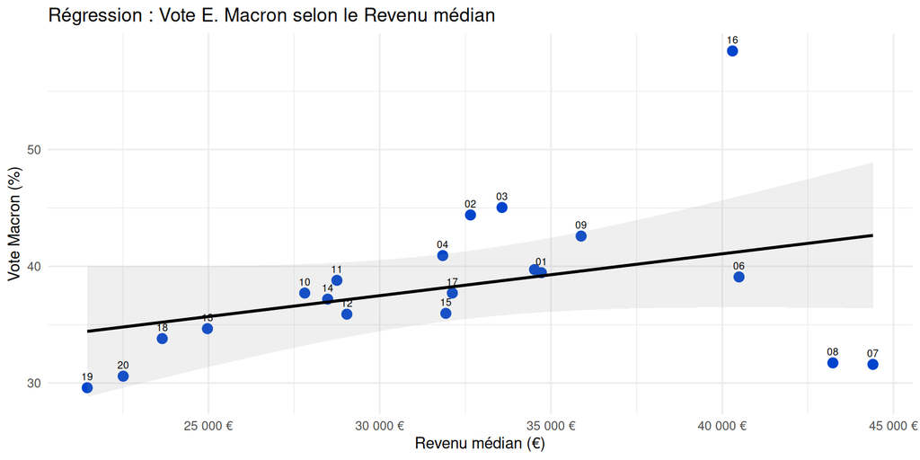

```r
ggplot(df, aes(x = Revenu, y = EM)) +
  geom_point(color = "#0044cc", size = 3) +
  geom_smooth(method = "lm", formula = y ~ x, color = "black", se = TRUE, alpha = 0.15) +
  geom_text(aes(label = str_sub(as.character(Arrondissement), -2)),
            size = 2.5, vjust = -1, check_overlap = TRUE) +
  scale_x_continuous(labels = label_number(big.mark = " ", suffix = " €")) +
  labs(
    title = "Régression : Vote E. Macron selon le Revenu médian",
    x = "Revenu médian (€)",
    y = "Vote Macron (%)"
  ) +
  theme_minimal()
```

**F. Fillon**

**Voir le code R**

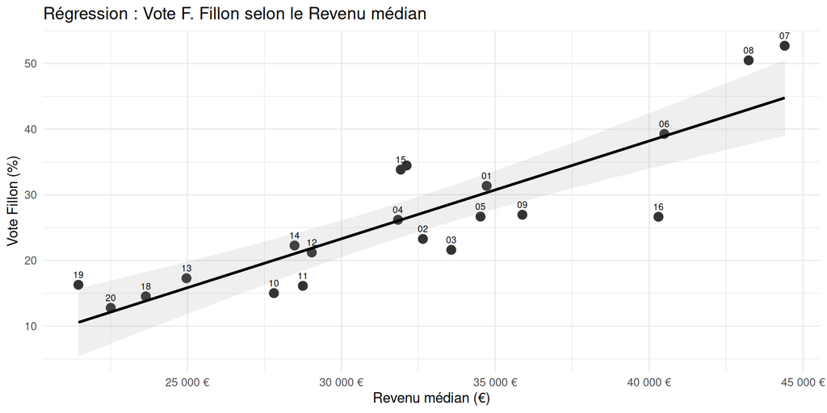

```r
ggplot(df, aes(x = Revenu, y = FF)) +
  geom_point(color = "#333333", size = 3) +
  geom_smooth(method = "lm", formula = y ~ x, color = "black", se = TRUE, alpha = 0.15) +
  geom_text(aes(label = str_sub(as.character(Arrondissement), -2)),
            size = 2.5, vjust = -1, check_overlap = TRUE) +
  scale_x_continuous(labels = label_number(big.mark = " ", suffix = " €")) +
  labs(
    title = "Régression : Vote F. Fillon selon le Revenu médian",
    x = "Revenu médian (€)",
    y = "Vote Fillon (%)"
  ) +
  theme_minimal()
```

**J.L. Mélenchon**

**Voir le code R**

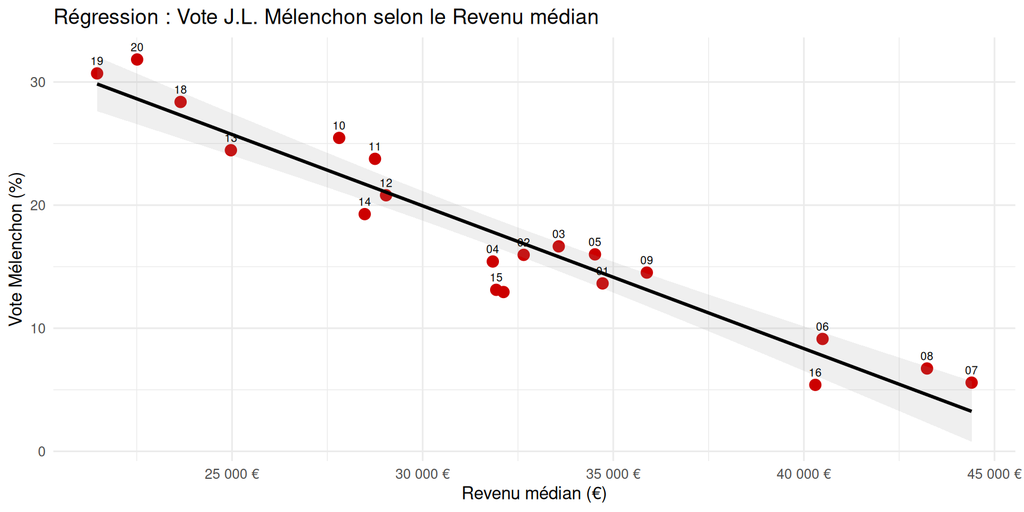

```r
ggplot(df, aes(x = Revenu, y = JLM)) +
  geom_point(color = "#cc0000", size = 3) +
  geom_smooth(method = "lm", formula = y ~ x, color = "black", se = TRUE, alpha = 0.15) +
  geom_text(aes(label = str_sub(as.character(Arrondissement), -2)),
            size = 2.5, vjust = -1, check_overlap = TRUE) +
  scale_x_continuous(labels = label_number(big.mark = " ", suffix = " €")) +
  labs(
    title = "Régression : Vote J.L. Mélenchon selon le Revenu médian",
    x = "Revenu médian (€)",
    y = "Vote Mélenchon (%)"
  ) +
  theme_minimal()
```

## 1.4 Q4 — Cartographie

Représentons sur quatre cartes les résultats pour JLM, FF, EM ainsi que le revenu médian.

**Voir le code R**

```r
library(sf)

# Chargement du GeoJSON des arrondissements de Paris
# Source : opendata.paris.fr
carte_paris <- st_read("data/arrondissements.geojson", quiet = TRUE) %>%
  mutate(cle_geo = as.numeric(c_ar))

# Jointure via le numéro d'arrondissement (1 à 20)
df_carto <- df %>%
  mutate(cle_arr = as.numeric(Arrondissement) %% 100)

paris_data <- carte_paris %>%
  left_join(df_carto, by = c("cle_geo" = "cle_arr"))

# Calcul des centroïdes pour les étiquettes d'arrondissement
centroids <- st_centroid(paris_data)
centroids_coords <- st_coordinates(centroids)
paris_data$label_x <- centroids_coords[, 1]
paris_data$label_y <- centroids_coords[, 2]
paris_data$label_arr <- paste0(paris_data$cle_geo, "e")

# Recentrer le 12e (décalé à cause du bois de Vincennes)
paris_data$label_x[paris_data$cle_geo == 12] <- 2.39
paris_data$label_y[paris_data$cle_geo == 12] <- 48.84
```

**J.L. Mélenchon**

**Voir le code R**

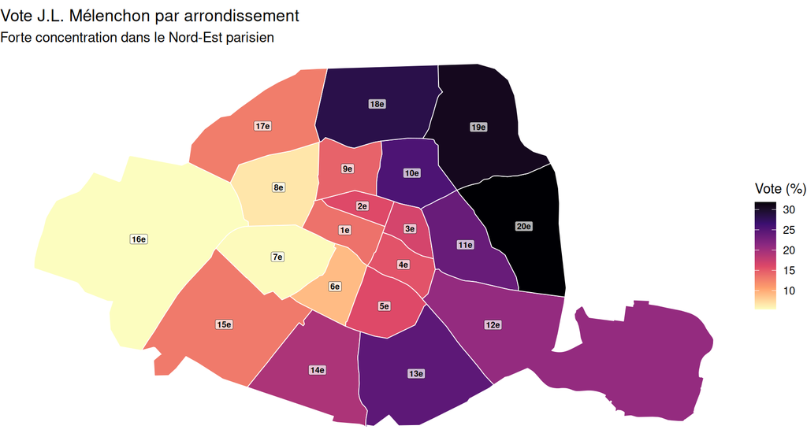

```r
ggplot(data = paris_data) +
  geom_sf(aes(fill = JLM), color = "white", linewidth = 0.3) +
  geom_label(aes(x = label_x, y = label_y, label = label_arr),
             size = 2.3, fontface = "bold", color = "black",
             fill = "white", alpha = 0.7, label.size = 0.1,
             label.padding = unit(1.5, "pt")) +
  scale_fill_viridis_c(option = "magma", direction = -1) +
  labs(
    title = "Vote J.L. Mélenchon par arrondissement",
    subtitle = "Forte concentration dans le Nord-Est parisien",
    fill = "Vote (%)"
  ) +
  theme_void()
```

**F. Fillon**

**Voir le code R**

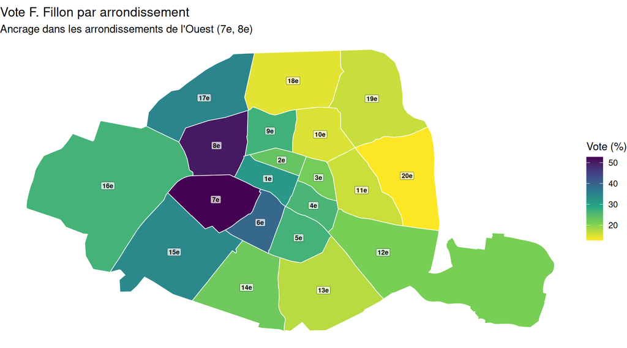

```r
ggplot(data = paris_data) +
  geom_sf(aes(fill = FF), color = "white", linewidth = 0.3) +
  geom_label(aes(x = label_x, y = label_y, label = label_arr),
             size = 2.3, fontface = "bold", color = "black",
             fill = "white", alpha = 0.7, label.size = 0.1,
             label.padding = unit(1.5, "pt")) +
  scale_fill_viridis_c(option = "viridis", direction = -1) +
  labs(
    title = "Vote F. Fillon par arrondissement",
    subtitle = "Ancrage dans les arrondissements de l'Ouest (7e, 8e)",
    fill = "Vote (%)"
  ) +
  theme_void()
```

**E. Macron**

**Voir le code R**

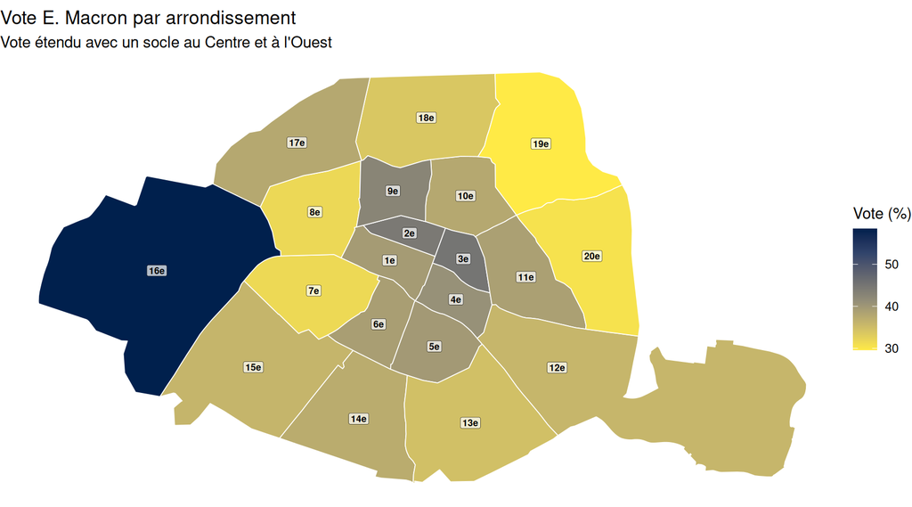

```r
ggplot(data = paris_data) +
  geom_sf(aes(fill = EM), color = "white", linewidth = 0.3) +
  geom_label(aes(x = label_x, y = label_y, label = label_arr),
             size = 2.3, fontface = "bold", color = "black",
             fill = "white", alpha = 0.7, label.size = 0.1,
             label.padding = unit(1.5, "pt")) +
  scale_fill_viridis_c(option = "cividis", direction = -1) +
  labs(
    title = "Vote E. Macron par arrondissement",
    subtitle = "Vote étendu avec un socle au Centre et à l'Ouest",
    fill = "Vote (%)"
  ) +
  theme_void()
```

**Revenu médian**

**Voir le code R**

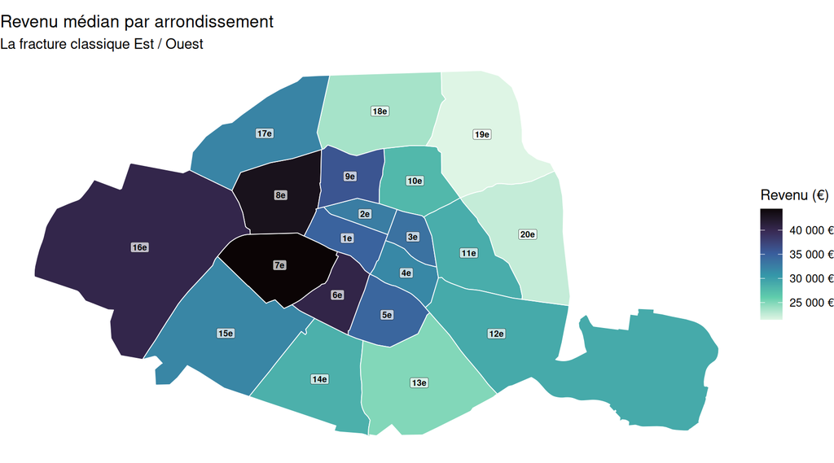

```r
ggplot(data = paris_data) +
  geom_sf(aes(fill = Revenu), color = "white", linewidth = 0.3) +
  geom_label(aes(x = label_x, y = label_y, label = label_arr),
             size = 2.3, fontface = "bold", color = "black",
             fill = "white", alpha = 0.7, label.size = 0.1,
             label.padding = unit(1.5, "pt")) +
  scale_fill_viridis_c(option = "mako", direction = -1,
                       labels = label_number(big.mark = " ", suffix = " €")) +
  labs(
    title = "Revenu médian par arrondissement",
    subtitle = "La fracture classique Est / Ouest",
    fill = "Revenu (€)"
  ) +
  theme_void()
```

## 1.5 Q5 — Nuage de points combiné

Représentons les proportions de vote pour FF, EM et JLM en fonction du revenu médian sur un même graphique, avec leurs droites de régression.

**Voir le code R**

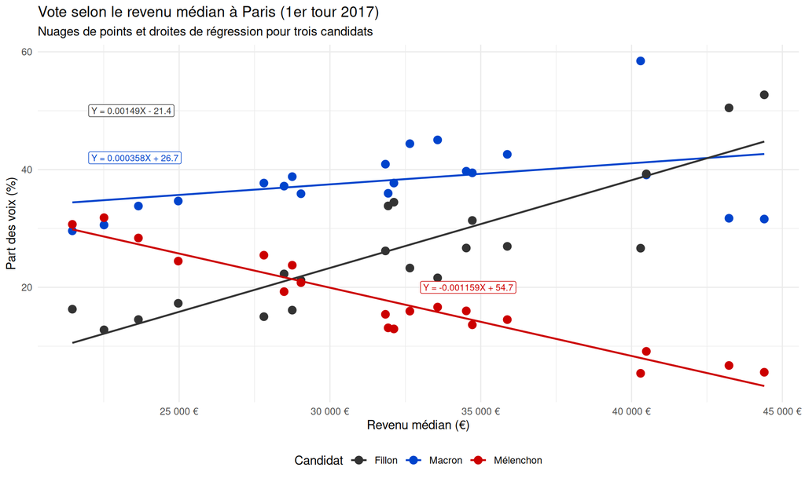

```r
# Calcul des équations pour les annotations
make_eq <- function(var) {
  m <- lm(df[[var]] ~ df$Revenu)
  a <- coef(m)[2]
  b <- coef(m)[1]
  signe <- ifelse(b >= 0, "+ ", "- ")
  paste0("Y = ", format(round(a, 6), scientific = FALSE), "X ", signe, abs(round(b, 1)))
}
eq_em  <- make_eq("EM")
eq_ff  <- make_eq("FF")
eq_jlm <- make_eq("JLM")

ggplot(df, aes(x = Revenu)) +
  # E. Macron
  geom_point(aes(y = EM, color = "Macron"), size = 3) +
  geom_smooth(aes(y = EM, color = "Macron"), method = "lm", formula = y ~ x,
              se = FALSE, linewidth = 0.8) +

  # F. Fillon
  geom_point(aes(y = FF, color = "Fillon"), size = 3) +
  geom_smooth(aes(y = FF, color = "Fillon"), method = "lm", formula = y ~ x,
              se = FALSE, linewidth = 0.8) +

  # J.L. Mélenchon
  geom_point(aes(y = JLM, color = "Mélenchon"), size = 3) +
  geom_smooth(aes(y = JLM, color = "Mélenchon"), method = "lm", formula = y ~ x,
              se = FALSE, linewidth = 0.8) +

  # Équations des droites de régression
  annotate("label", x = 22000, y = 42, label = eq_em,
           color = "#0044cc", size = 2.8, hjust = 0, fill = "white", alpha = 0.8,
           label.size = 0) +
  annotate("label", x = 22000, y = 50, label = eq_ff,
           color = "#333333", size = 2.8, hjust = 0, fill = "white", alpha = 0.8,
           label.size = 0) +
  annotate("label", x = 33000, y = 20, label = eq_jlm,
           color = "#cc0000", size = 2.8, hjust = 0, fill = "white", alpha = 0.8,
           label.size = 0) +

  # Couleurs et légende
  scale_color_manual(values = c(
    "Macron" = "#0044cc",
    "Fillon" = "#333333",
    "Mélenchon" = "#cc0000"
  )) +
  scale_x_continuous(labels = label_number(big.mark = " ", suffix = " €")) +

  labs(
    title = "Vote selon le revenu médian à Paris (1er tour 2017)",
    subtitle = "Nuages de points et droites de régression pour trois candidats",
    x = "Revenu médian (€)",
    y = "Part des voix (%)",
    color = "Candidat"
  ) +
  theme_minimal() +
  theme(legend.position = "bottom")
```

# 2 Partie 2 : Analyse et restitution

## 2.1 Introduction

Le 23 avril 2017, le premier tour de l’élection présidentielle française se tient dans un contexte politique inédit : quatre candidats se disputent l’accès au second tour, incarnant chacun une offre politique distincte. **Emmanuel Macron** (En Marche, centre-droit), **François Fillon** (LR, droite), **Jean-Luc Mélenchon** (LFI, gauche) et **Marine Le Pen** (RN, extrême droite) rassemblent à eux quatre plus de 80 % des suffrages exprimés au niveau national.

Paris constitue un des terrains d’analyse privilégiés pour les sciences sociales : ses 20 arrondissements présentent des profils socio-économiques extrêmement contrastés, allant des quartiers populaires du Nord-Est (18<sup>e</sup>, 19<sup>e</sup>, 20<sup>e</sup>) aux arrondissements les plus aisés de l’Ouest (7<sup>e</sup>, 8<sup>e</sup>, 16<sup>e</sup>). Notre jeu de données comprend les résultats électoraux de ces 20 arrondissements, ainsi que le revenu médian des ménages par unité de consommation (source INSEE, 2019).

## 2.2 Problématique

**Le revenu médian des ménages est-il un prédicteur fiable du vote dans les arrondissements parisiens ?** En d’autres termes, peut-on établir une relation statistique entre le niveau de vie d’un arrondissement et l’orientation politique de ses habitants ?

## 2.3 Paris, une ville économiquement polarisée

Avant d’examiner les votes, il convient de caractériser le paysage socio-économique parisien.

**Voir le code R**

```r
# Indicateurs clés sur le revenu
rev_stats <- tibble(
  Indicateur = c("Minimum", "Q1", "Médiane", "Q3", "Maximum", "EIQ", "Écart-type"),
  Valeur = c(
    min(df$Revenu), quantile(df$Revenu, 0.25),
    median(df$Revenu), quantile(df$Revenu, 0.75),
    max(df$Revenu),
    quantile(df$Revenu, 0.75) - quantile(df$Revenu, 0.25),
    sd(df$Revenu)
  )
) %>%
  mutate(Valeur = paste0(format(round(Valeur, 0), big.mark = " "), " €"))

kable(rev_stats, align = "lr")
```

| Indicateur | Valeur |
| --- | --- |
| Minimum | 21 460 € |
| Q1 | 28 312 € |
| Médiane | 32 025 € |
| Q3 | 35 010 € |
| Maximum | 44 400 € |
| EIQ | 6 698 € |
| Écart-type | 6 577 € |

Le revenu médian varie de **21 460 €** (19<sup>e</sup> arr.) à **44 400 €** (7<sup>e</sup> arr.), soit un rapport de 1 à 2. L’écart inter-quartile (EIQ) de **6 698 €** indique que la moitié centrale des arrondissements est concentrée dans une fourchette relativement étroite, tandis que les extrêmes (les arrondissements très aisés de l’Ouest et les quartiers populaires du Nord-Est) tirent la distribution vers ses bornes. Paris est une ville à deux visages économiques, séparée par une fracture Est/Ouest bien documentée en sociologie urbaine.

## 2.4 De la richesse au vote : des dynamiques contrastées

L’analyse bivariée (corrélation et régression) confirme que le revenu médian est un **prédicteur puissant** du comportement électoral, mais avec des intensités très variables selon les candidats.

### 2.4.1 J.L. Mélenchon : le vote des quartiers populaires

Mélenchon affiche la corrélation la plus forte de notre analyse : $r = -0{,}955$, soit un $R^2 = 0{,}912$. Cela signifie que **91 % des écarts de vote pour Mélenchon d’un arrondissement à l’autre s’expliquent par la seule différence de revenu**. La relation est négative : plus l’arrondissement est modeste, plus le vote Mélenchon est élevé.

La droite de régression ($Y = -0{,}001159 \times Revenu + 54{,}72$) indique qu’une augmentation de 1 000 € du revenu médian est associée à une baisse d’environ 1,2 point du vote Mélenchon.

### 2.4.2 F. Fillon : le candidat des arrondissements aisés

Fillon est le symétrique de Mélenchon : $r = +0{,}871$, $R^2 = 0{,}759$. Le revenu explique **76 % de la variation** de son vote. La pente de sa droite de régression est la plus forte des trois candidats ($a = 0{,}001490$), ce qui signifie qu’il est le plus sensible au niveau de richesse.

Son score culmine dans le 7<sup>e</sup> arrondissement (52,70 %, revenu : 44 400 €) et le 8<sup>e</sup> (50,48 %, revenu : 43 230 €). En dehors de ces bastions historiques de la droite traditionnelle, le vote Fillon chute rapidement. Son EIQ de **14,94 points** confirme une dispersion élevée : le candidat de la droite ne touche pas les mêmes arrondissements que les autres.

### 2.4.3 E. Macron : un centriste atypiquement stable

Macron présente un profil singulier. Sa corrélation avec le revenu est positive mais modérée ($r = +0{,}366$, $R^2 = 0{,}134$). Le revenu n’explique que **13 % de la variation** de son vote, ce qui en fait le candidat le moins “prévisible” par le seul critère économique.

Cette stabilité se lit dans ses indicateurs de dispersion : un écart-type de **6,44 points** (le plus faible après Le Pen) et un EIQ de **5,57 points** seulement. Macron oscille entre 29,60 % (19<sup>e</sup> arr.) et 58,45 % (16<sup>e</sup> arr.), mais sa médiane est haute (**37,71 %**) et sa base électorale est **présente dans quasiment tous les arrondissements**, des plus modestes aux plus riches.

Le score exceptionnel du 16<sup>e</sup> arrondissement (58,45 %) est un point atypique qui mérite attention : il suggère que des facteurs autres que le revenu (profil sociologique, CSP, trajectoire résidentielle) interviennent dans la structuration du vote Macron.

### 2.4.4 M. Le Pen : la grande absente de la géographie parisienne

Le Pen est la variable la plus homogène de notre jeu de données : son vote oscille entre **3,22 %** (6<sup>e</sup> arr.) et **6,48 %** (13<sup>e</sup> arr.), soit un EIQ dérisoire de **1,45 point** et un écart-type de seulement **0,98 point**. La corrélation avec le revenu est négative ($r = -0{,}681$), mais le vote reste uniformément faible quel que soit l’arrondissement.

Paris intra-muros n’est pas le terrain du vote Le Pen, qui s’exprime davantage dans les zones périurbaines et rurales. L’électorat RN est sociologiquement absent de la capitale.

## 2.5 Conclusion

L’analyse des résultats du premier tour 2017 dans les 20 arrondissements parisiens met en lumière une **structure socio-électorale fortement corrélée au revenu**. La fracture géographique Est/Ouest de Paris, qui oppose les quartiers populaires du Nord-Est aux arrondissements aisés du Centre-Ouest, se superpose quasi parfaitement à la fracture électorale.

Mélenchon et Fillon représentent les deux pôles extrêmes de cette relation : leurs votes se substituent l’un à l’autre le long de l’axe des revenus, avec des $R^2$ supérieurs à 0,75. Macron, en revanche, traverse les catégories de revenu avec une stabilité remarquable, confirmant son positionnement centriste. Le Pen reste uniformément marginale à Paris.

**Limites de l’analyse :**

1. **Corrélation n’est pas causalité** : le revenu ne “cause” pas directement le vote. Il est lui-même corrélé à d’autres variables (niveau d’éducation, CSP, origine sociale) qui influencent les préférences politiques.
2. **Effet écologique** : nous raisonnons à l’échelle de l’arrondissement (n = 20), pas de l’individu. Ce sont des moyennes territoriales. Un arrondissement à revenu élevé contient aussi des habitants modestes, et inversement.
3. **Taille de l’échantillon** : avec seulement 20 observations, les résultats statistiques sont à interpréter avec prudence. La significativité des coefficients est limitée par ce petit effectif.

**AstuceBonne pratique : conclure avec les limites**

Un rapport d’analyse rigoureux ne se contente pas de présenter des résultats ; il en discute les **limites**. Mentionner que corrélation n’est pas causalité, et que le raisonnement écologique a ses biais, est un signe de maturité analytique.

# 3 Annexe : Erreurs fréquentes observées dans les copies

**Important1. Présenter la variance sans l’écart-type**

La variance est une étape de calcul, pas un indicateur d’interprétation. Toujours calculer l’écart-type ($\sigma = \sqrt{V}$), qui est dans la même unité que les données et permet une lecture directe : “en moyenne, les arrondissements s’écartent de X points de la moyenne”.

**Important2. Confondre $r$ et $R^2$**

Le coefficient de corrélation ($r$) mesure l’intensité du lien linéaire (entre -1 et 1). Le coefficient de détermination ($R^2$) mesure la part de variance expliquée (entre 0 et 1). Dire “la corrélation est de 0,92” est correct ; dire “le revenu explique 92 % du vote” n’est correct que si l’on parle du $R^2$ (qui vaut ici $0,92^2 = 0,85$).

**Important3. Analyse sociologique sans appui statistique**

Affirmer que “le vote Mélenchon est corrélé aux quartiers populaires” sans mentionner le coefficient de corrélation ni le $R^2$ prive le propos de sa rigueur. Inversement, aligner des chiffres sans les interpréter ne constitue pas une analyse. Les deux dimensions (chiffres et interprétation) doivent coexister.

**Important4. Graphiques sans titres, sans unités**

Chaque graphique doit comporter un **titre explicite**, des **axes légendés** avec leurs unités (%, €), et des **séparateurs de milliers** pour les montants. Un graphique non légendé est inutilisable pour un lecteur extérieur.

**Important5. Absence de structure (intro, problématique, conclusion)**

Un rapport professionnel suit une structure : introduction avec contexte et problématique, corps d’analyse du général vers le particulier, et conclusion avec synthèse et limites. Sans ce cadre, le lecteur est perdu.